# Partie B sujet 1, visualisation_skmeans_von-Mises-Fischer

Binome : - Wacim BELAHCEL - Imad Oualid KACIMI

### Remarque : Dans cette partie nous avons décider de garder 50 mot pour faciliter la visualization.

```r
library(FactoMineR)
library(Factoshiny)
library(stats)
library(skmeans)
library(clusterSim)
library(aricode)
library(movMF)

spam=read.csv("C:\\Users\\imadw\\Desktop\\textmining\\spam_cocurence_50.csv")
spam
```

| back | call | come | da | day | dont | free | get | go | good | got | gt | hi | home | httpaddr | know | like | lor | love | lt | make | mobil | need | numbr | numbrp | ok | one | onli | phone | pleas | … |
| --- | --- | --- | --- | --- | --- | --- | --- | --- | --- | --- | --- | --- | --- | --- | --- | --- | --- | --- | --- | --- | --- | --- | --- | --- | --- | --- | --- | --- | --- | --- |
| 0 | 0 | 0 | 0 | 0 | 0 | 0 | 0 | 1 | 0 | 1 | 0 | 0 | 0 | 0 | 0 | 0 | 0 | 0 | 0 | 0 | 0 | 0 | 0 | 0 | 0 | 0 | 1 | 0 | 0 | … |
| 0 | 0 | 0 | 0 | 0 | 0 | 0 | 0 | 0 | 0 | 0 | 0 | 0 | 0 | 0 | 0 | 0 | 0 | 0 | 0 | 0 | 0 | 0 | 0 | 0 | 1 | 0 | 0 | 0 | 0 | … |
| 0 | 0 | 0 | 0 | 0 | 0 | 1 | 0 | 0 | 0 | 0 | 0 | 0 | 0 | 0 | 0 | 0 | 0 | 0 | 0 | 0 | 0 | 0 | 3 | 0 | 0 | 0 | 0 | 0 | 0 | … |
| 0 | 0 | 0 | 0 | 0 | 0 | 0 | 0 | 0 | 0 | 0 | 0 | 0 | 0 | 0 | 0 | 0 | 0 | 0 | 0 | 0 | 0 | 0 | 0 | 0 | 0 | 0 | 0 | 0 | 0 | … |
| 0 | 0 | 0 | 0 | 0 | 0 | 0 | 0 | 0 | 0 | 0 | 0 | 0 | 0 | 0 | 0 | 0 | 0 | 0 | 0 | 0 | 0 | 0 | 0 | 0 | 0 | 0 | 0 | 0 | 0 | … |
| 1 | 0 | 0 | 0 | 0 | 0 | 0 | 0 | 0 | 0 | 0 | 0 | 0 | 0 | 0 | 0 | 1 | 0 | 0 | 0 | 0 | 0 | 0 | 1 | 0 | 1 | 0 | 0 | 0 | 0 | … |
| 0 | 0 | 0 | 0 | 0 | 0 | 0 | 0 | 0 | 0 | 0 | 0 | 0 | 0 | 0 | 0 | 2 | 0 | 0 | 0 | 0 | 0 | 0 | 0 | 0 | 0 | 0 | 0 | 0 | 0 | … |
| 0 | 0 | 0 | 0 | 0 | 0 | 0 | 0 | 0 | 0 | 0 | 0 | 0 | 0 | 0 | 0 | 0 | 0 | 0 | 0 | 0 | 0 | 0 | 1 | 0 | 0 | 0 | 0 | 0 | 0 | … |
| 0 | 1 | 0 | 0 | 0 | 0 | 0 | 0 | 0 | 0 | 0 | 0 | 0 | 0 | 0 | 0 | 0 | 0 | 0 | 0 | 0 | 0 | 0 | 2 | 0 | 0 | 0 | 1 | 0 | 0 | … |
| 0 | 1 | 0 | 0 | 0 | 0 | 2 | 0 | 0 | 0 | 0 | 0 | 0 | 0 | 0 | 0 | 0 | 0 | 0 | 0 | 0 | 3 | 0 | 2 | 0 | 0 | 0 | 0 | 0 | 0 | … |

[output cut: 990 more lines]

```r
colnames <- names(spam)
colnames
```

```
 [1] "back"             "call"             "come"
 [4] "da"               "day"              "dont"
 [7] "free"             "get"              "go"
[10] "good"             "got"              "gt"
[13] "hi"               "home"             "httpaddr"
[16] "know"             "like"             "lor"
[19] "love"             "lt"               "make"
[22] "mobil"            "need"             "numbr"
[25] "numbrp"           "ok"               "one"
[28] "onli"             "phone"            "pleas"
[31] "repli"            "say"              "see"
[34] "send"             "sorri"            "still"
[37] "stop"             "take"             "tell"
[40] "text"             "thi"              "think"
[43] "time"             "today"            "txt"
[46] "ur"               "wa"               "want"
[49] "week"             "Ã.moneysymbnumbr" "spam_class"
```

```r
# extraite la table des co-occurences
spamq=data.frame(matrix(as.factor(as.matrix(spam[,1:51]>0)),ncol=51))
names(spamq) <- colnames

spamq
```

| back | call | come | da | day | dont | free | get | go | good | got | gt | hi | home | httpaddr | know | like | lor | love | lt | make | mobil | need | numbr | numbrp | ok | one | onli | phone | pleas | … |
| --- | --- | --- | --- | --- | --- | --- | --- | --- | --- | --- | --- | --- | --- | --- | --- | --- | --- | --- | --- | --- | --- | --- | --- | --- | --- | --- | --- | --- | --- | --- |
| FALSE | FALSE | FALSE | FALSE | FALSE | FALSE | FALSE | FALSE | TRUE | FALSE | TRUE | FALSE | FALSE | FALSE | FALSE | FALSE | FALSE | FALSE | FALSE | FALSE | FALSE | FALSE | FALSE | FALSE | FALSE | FALSE | FALSE | TRUE | FALSE | FALSE | … |
| FALSE | FALSE | FALSE | FALSE | FALSE | FALSE | FALSE | FALSE | FALSE | FALSE | FALSE | FALSE | FALSE | FALSE | FALSE | FALSE | FALSE | FALSE | FALSE | FALSE | FALSE | FALSE | FALSE | FALSE | FALSE | TRUE | FALSE | FALSE | FALSE | FALSE | … |
| FALSE | FALSE | FALSE | FALSE | FALSE | FALSE | TRUE | FALSE | FALSE | FALSE | FALSE | FALSE | FALSE | FALSE | FALSE | FALSE | FALSE | FALSE | FALSE | FALSE | FALSE | FALSE | FALSE | TRUE | FALSE | FALSE | FALSE | FALSE | FALSE | FALSE | … |
| FALSE | FALSE | FALSE | FALSE | FALSE | FALSE | FALSE | FALSE | FALSE | FALSE | FALSE | FALSE | FALSE | FALSE | FALSE | FALSE | FALSE | FALSE | FALSE | FALSE | FALSE | FALSE | FALSE | FALSE | FALSE | FALSE | FALSE | FALSE | FALSE | FALSE | … |
| FALSE | FALSE | FALSE | FALSE | FALSE | FALSE | FALSE | FALSE | FALSE | FALSE | FALSE | FALSE | FALSE | FALSE | FALSE | FALSE | FALSE | FALSE | FALSE | FALSE | FALSE | FALSE | FALSE | FALSE | FALSE | FALSE | FALSE | FALSE | FALSE | FALSE | … |
| TRUE | FALSE | FALSE | FALSE | FALSE | FALSE | FALSE | FALSE | FALSE | FALSE | FALSE | FALSE | FALSE | FALSE | FALSE | FALSE | TRUE | FALSE | FALSE | FALSE | FALSE | FALSE | FALSE | TRUE | FALSE | TRUE | FALSE | FALSE | FALSE | FALSE | … |
| FALSE | FALSE | FALSE | FALSE | FALSE | FALSE | FALSE | FALSE | FALSE | FALSE | FALSE | FALSE | FALSE | FALSE | FALSE | FALSE | TRUE | FALSE | FALSE | FALSE | FALSE | FALSE | FALSE | FALSE | FALSE | FALSE | FALSE | FALSE | FALSE | FALSE | … |
| FALSE | FALSE | FALSE | FALSE | FALSE | FALSE | FALSE | FALSE | FALSE | FALSE | FALSE | FALSE | FALSE | FALSE | FALSE | FALSE | FALSE | FALSE | FALSE | FALSE | FALSE | FALSE | FALSE | TRUE | FALSE | FALSE | FALSE | FALSE | FALSE | FALSE | … |
| FALSE | TRUE | FALSE | FALSE | FALSE | FALSE | FALSE | FALSE | FALSE | FALSE | FALSE | FALSE | FALSE | FALSE | FALSE | FALSE | FALSE | FALSE | FALSE | FALSE | FALSE | FALSE | FALSE | TRUE | FALSE | FALSE | FALSE | TRUE | FALSE | FALSE | … |
| FALSE | TRUE | FALSE | FALSE | FALSE | FALSE | TRUE | FALSE | FALSE | FALSE | FALSE | FALSE | FALSE | FALSE | FALSE | FALSE | FALSE | FALSE | FALSE | FALSE | FALSE | TRUE | FALSE | TRUE | FALSE | FALSE | FALSE | FALSE | FALSE | FALSE | … |

[output cut: 990 more lines]

```r
Factoshiny(spamq)
```

```
Listening on http://127.0.0.1:3242
```

```
NA
```

#Partie B:

## Q1

Test de visualisation avec une afc en utilisant la matrice d’occurence seuelemnt o nremarque que les point sont trés superposé et melangé. nous avons donc fait une 2eme visualisation en appliquant une afcm sur la table de co-occurence.

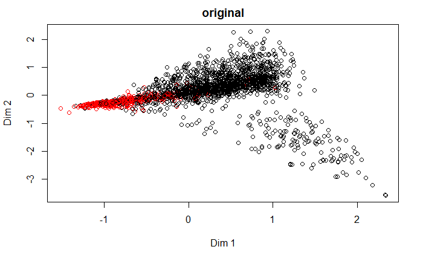

```r
spam_occ <- spam[rowSums(spam[,1:50]) != 0, ]
res.CA<-CA(spam_occ[rowSums(spam_occ[, 1:50]) != 0, ],col.sup=c(51),graph=FALSE)
plot(res.CA$row$coord,col=as.factor(spam_occ[,51]), main = "original")
```

en appliquant une afcm sur notre table de co-occurence et en gardant les individus qui cntribuent le plus, on peut remarquer 2 cluster plus au moin lineairement séparable.

en affichant les modalitées, on peut remarquer que le 1 er axe est correlé avec la modalité spam_true, on peeut aussi remarquer que les autres variables qui sont le plus correlés avec ce meme axe sont : free_true phone_true numbr_true, moneysymbole_true… qui ont donc le plus contribués à la création de l’axe et sont des variables qui souvent sont trouvé dans des mails spam, ce qui peux expliquer pourquoi cet axe permet de separer nos deux classes. Pour le 2eme axes on peut remarquer qu’il est plus carracterisé par des mot plutot que des chiffres

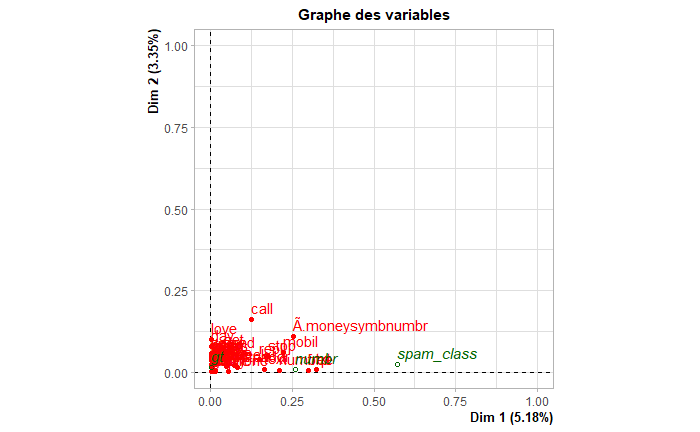

```r
res.MCA<-MCA(spamq,quali.sup=c(12,24,51),graph=FALSE)
plot.MCA(res.MCA, choix='var',title="Graphe des variables")
```

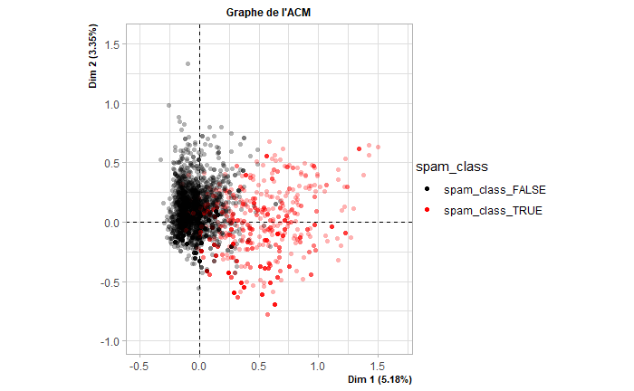

```r
plot.MCA(res.MCA,invisible= c('var','quali.sup'),select= 'contrib 491',habillage=51,title="Graphe de l'ACM",cex=0.85,cex.main=0.85,cex.axis=0.85,label ="none")
```

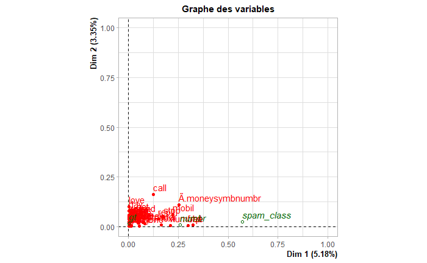

```r
res.MCA<-MCA(spamq,quali.sup=c(12,24,51),graph=FALSE)
plot.MCA(res.MCA, choix='var',title="Graphe des variables",col.quali.sup='#006400')
```

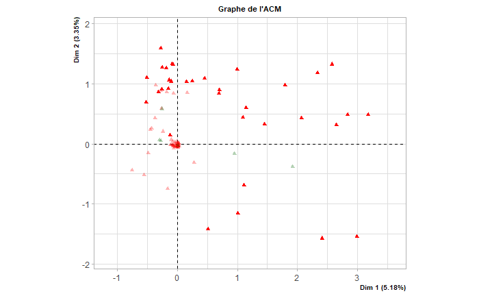

```r
plot.MCA(res.MCA,invisible= 'ind',select= 'contrib 443',selectMod= 'contrib  34 ',col.quali.sup='#006400',title="Graphe de l'ACM",cex=0.75,cex.main=0.75,cex.axis=0.75,label =c('var','quali.sup'))
```

## Q2 :

L’algorithme choisit est le spherical kmeans, car on s’interesse plus à regrouper les données selon leur direction et non pas leur distance au sens euclidien (plutot la cosine similarité qui représente l’angle entre les vecteurs)

```r
## transformation en numeric
spamq2=data.frame(matrix(as.numeric(as.matrix(spamq[,1:51]>0)),ncol=51))
names(spamq2) <- colnames
```

```r
#spamq2 <- spamq2[rowSums(spamq2[,1:50]) != 0, ]
zs.skmeans <- skmeans(as.matrix(spam[1:50]+0.001), 2)
table(zs.skmeans$cluster,spam[,51])
```

```
       0    1
  1  564  672
  2 4261   75
```

```r
print(" ")
```

```
[1] " "
```

```r
print(" ")
```

```
[1] " "
```

```r
print(paste("Accuracy: ", comparing.Partitions(zs.skmeans$cluster,as.vector(as.matrix(spam[,51])))))
```

```
[1] "Accuracy:  0.713399064339252"
```

```r
print(paste("NMI: ", NMI(zs.skmeans$cluster,as.vector(as.matrix(spam[,51])))))
```

```
[1] "NMI:  0.327237386788997"
```

```r
print(paste("ARI: ", ARI(zs.skmeans$cluster,as.vector(as.matrix(spam[,51])))))
```

```
[1] "ARI:  0.513136388652975"
```

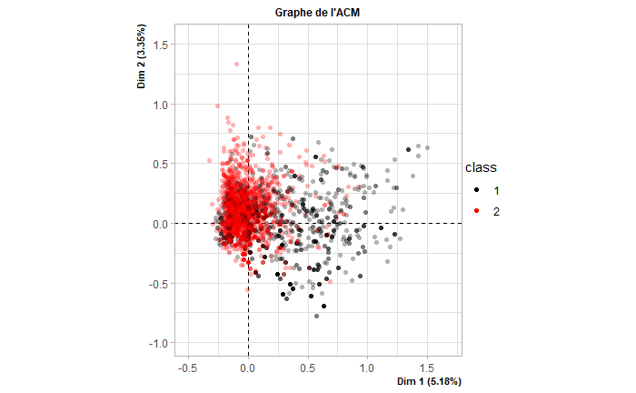

```r
spamq$class <- as.factor(zs.skmeans$cluster)
res.MCA<-MCA(spamq,quali.sup=c(12,24,51,52),graph=FALSE)

plot.MCA(res.MCA,invisible= c('var','quali.sup'),select= 'contrib 491',habillage=52,title="Graphe de l'ACM",cex=0.85,cex.main=0.85,cex.axis=0.85,label =c('none'))
```

# Q3:

On peut remarquer qu’on dispose de 3 cluster, un des cluster semble isolé suelement les 2 autres semble etre trop melangé, on remarque aussi une perte de performance sur l’accuracy, NMI et ARI.

```r
zs.skmeans <- skmeans(as.matrix(spam[1:50]+0.001), 3)
table(zs.skmeans$cluster,spam[,51])
```

```
       0    1
  1 1059    8
  2  587  671
  3 3179   68
```

```r
print("")
```

```
[1] ""
```

```r
print("")
```

```
[1] ""
```

```r
print(paste("Accuracy: ", comparing.Partitions(zs.skmeans$cluster,as.vector(as.matrix(spam[,51])))))
```

```
[1] "Accuracy:  0.520794945509362"
```

```r
print(paste("NMI: ", NMI(zs.skmeans$cluster,as.vector(as.matrix(spam[,51])))))
```

```
[1] "NMI:  0.176112807099765"
```

```r
print(paste("ARI: ", ARI(zs.skmeans$cluster,as.vector(as.matrix(spam[,51])))))
```

```
[1] "ARI:  0.220156446440229"
```

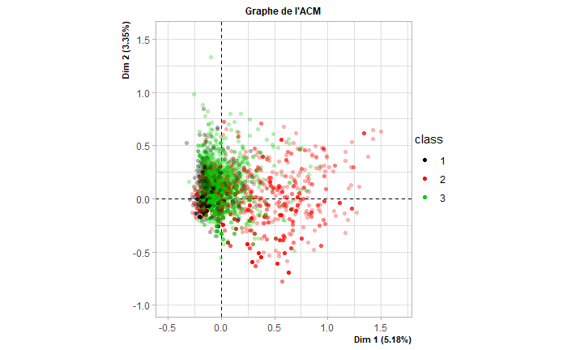

```r
spamq$class <- as.factor(zs.skmeans$cluster)
res.MCA<-MCA(spamq,quali.sup=c(12,24,51,52),graph=FALSE)

plot.MCA(res.MCA,invisible= c('var','quali.sup'),select= 'contrib 491',habillage=52,title="Graphe de l'ACM",cex=0.85,cex.main=0.85,cex.axis=0.85,label =c('none'))
```

## Q7:

```r
library(movMF)


res.vmf <- movMF(as.matrix(spam[1:50]+0.001), 2, nruns = 50, maxiter=400)
Fitted = predict(res.vmf)
table(Fitted,spam[,51])
```

```
Fitted    0    1
     1  317  476
     2 4508  271
```

```r
print(comparing.Partitions(Fitted,as.vector(as.matrix(spam[,51]))))
```

```
[1] 0.7672764
```

```r
print(NMI(Fitted,as.vector(as.matrix(spam[,51]))))
```

```
[1] 0.2724217
```

```r
print(ARI(Fitted,as.vector(as.matrix(spam[,51]))))
```

```
[1] 0.4798285
```

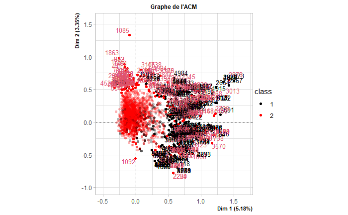

```r
spamq$class <- as.factor(Fitted)
res.MCA<-MCA(spamq,quali.sup=c(12,24,51,52),graph=FALSE)

plot.MCA(res.MCA,invisible= c('var','quali.sup'),select= 'contrib 491',habillage=52,title="Graphe de l'ACM",cex=0.85,cex.main=0.85,cex.axis=0.85,label =c('ind'))
```

# Utilisation de 1000 features :

Dans cette partie nous allons utilisé 1000 features au lieux de 50

```r
spam=read.csv("C:\\Users\\imadw\\Desktop\\textmining\\spam_cocurence_1000.csv")
colnames <- names(spam)

# extraite la table des co-occurences
spamq=data.frame(matrix(as.factor(as.matrix(spam[,1:1001]>0)),ncol=1001))
names(spamq) <- colnames
```

## Q1:

En appliquant une afcm sur notre table de co-occurence et en gardant les individus qui cntribuent le plus, on peut remarquer 2 cluster plus au moin lineairement séparable. on a eu presque le meme résultat qu’avec 50 features.

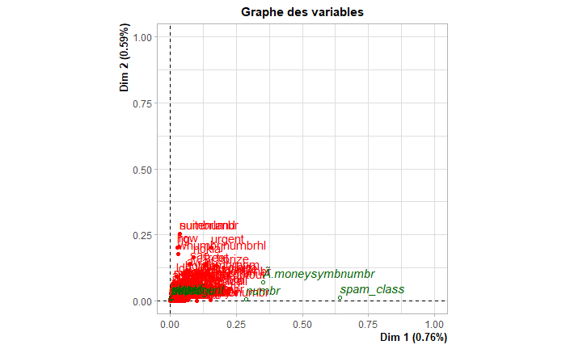

```r
res.MCA<-MCA(spamq,quali.sup=c(143,265,399,577,666,808,954,996,1001),graph=FALSE)
plot.MCA(res.MCA, choix='var',title="Graphe des variables")
```

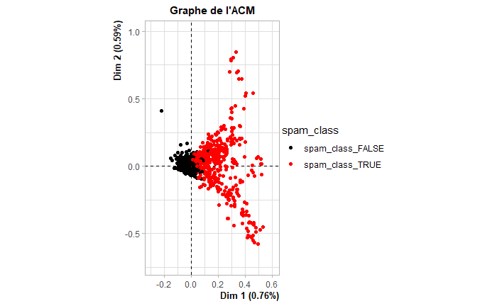

```r
plot.MCA(res.MCA,invisible= c('var','quali.sup'),habillage=1001,title="Graphe de l'ACM",label ='none')
```

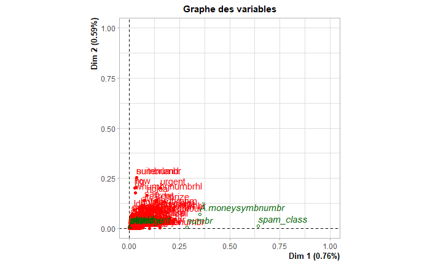

```r
res.MCA<-MCA(spamq,quali.sup=c(143,265,399,577,666,808,954,996,1001),graph=FALSE)
plot.MCA(res.MCA, choix='var',title="Graphe des variables")
```

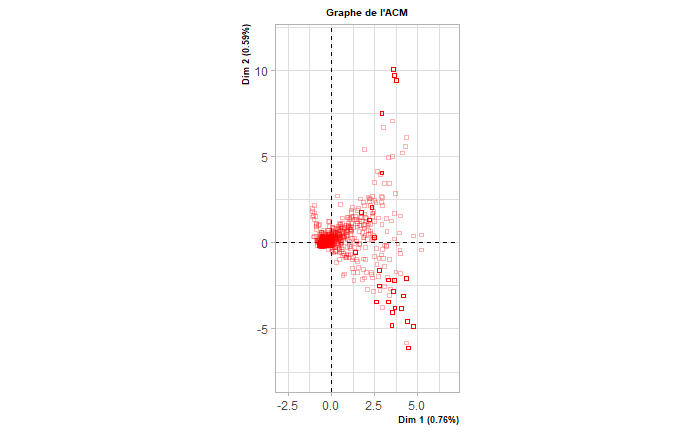

```r
plot.MCA(res.MCA,invisible= c('ind','quali.sup'),selectMod= 'contrib  27 ',habillage=1001,title="Graphe de l'ACM",cex=0.7,cex.main=0.7,cex.axis=0.7,label =c('var'))
```

## Q2:

On obtient des résultat equivalent a celle obtenue avec 50 features.

```r
zs.skmeans <- skmeans(as.matrix(spam[1:1000]+0.001), 2)
table(zs.skmeans$cluster,spam[,1001])
```

```
       0    1
  1 4260   72
  2  565  675
```

```r
print(" ")
```

```
[1] " "
```

```r
print(" ")
```

```
[1] " "
```

```r
print(paste("Accuracy: ", comparing.Partitions(zs.skmeans$cluster,as.vector(as.matrix(spam[,1001])))))
```

```
[1] "Accuracy:  0.713628196556911"
```

```r
print(paste("NMI: ", NMI(zs.skmeans$cluster,as.vector(as.matrix(spam[,1001])))))
```

```
[1] "NMI:  0.32994461883857"
```

```r
print(paste("ARI: ", ARI(zs.skmeans$cluster,as.vector(as.matrix(spam[,1001])))))
```

```
[1] "ARI:  0.514960310524129"
```

## Q7:

```r
res.vmf <- movMF(as.matrix(spam[1:1000]+0.001), 2, nruns = 50, maxiter=400)
Fitted = predict(res.vmf)
table(Fitted,spam[,1001])
```

```
Fitted    0    1
     1  291  504
     2 4534  243
```

```r
print(comparing.Partitions(Fitted,as.vector(as.matrix(spam[,1001]))))
```

```
[1] 0.7868257
```

```r
print(NMI(Fitted,as.vector(as.matrix(spam[,1001]))))
```

```
[1] 0.3122245
```

```r
print(ARI(Fitted,as.vector(as.matrix(spam[,1001]))))
```

```
[1] 0.5228424
```